# 431 Lab 5

Author

Shraddha Dumawat

Published

2024-11-06

## R Setup

```r
library(haven)
library(easystats)
library(tidyverse)
library(kableExtra)
library(ggplot2)
library(ggdist)
library(Epi)
library(janitor)
library(patchwork)

theme_set(theme_bw())
knitr::opts_chunk$set(comment = NA)
```

## Lovedist package

```r
##Loading Lovedist and packages

#| message: false


## should you choose to use the Love-431.R script, source it in here...
`lovedist` <- function(x) {
  tibble::tibble(
    n = length(x),
    miss = sum(is.na(x)),
    mean = mean(x, na.rm = TRUE),
    sd = sd(x, na.rm = TRUE),
    med = median(x, na.rm = TRUE),
    mad = mad(x, na.rm = TRUE),
    min = min(x, na.rm = TRUE),
    q25 = quantile(x, 0.25, na.rm = TRUE),
    q75 = quantile(x, 0.75, na.rm = TRUE),
    max = max(x, na.rm = TRUE),
  )
}

`twobytwo` <-
  function(a,b,c,d,
           namer1 = "Row1", namer2 = "Row2",
           namec1 = "Col1", namec2 = "Col2",
           conf.level = 0.95)
    # build 2 by 2 table and run Epi library's twoby2 command to summarize
    # from the row-by-row counts in a cross-tab
    # upper left cell is a, upper right is b,
    # lower left is c, lower right is d
    # names are then given in order down the rows then across the columns
    # use standard epidemiological format:
    # outcomes in columns, treatments in rows
  {
    .Table <- matrix(c(a, b, c, d), 2, 2, byrow=T,
                     dimnames=list(c(namer1, namer2),
                                   c(namec1, namec2)))
    Epi::twoby2(.Table, alpha = 1 - conf.level)
  }


`saifs_ci` <-
  function(x, n, conf.level=0.95, dig=3)
  {
    p.sample <- round(x/n, digits=dig)

    p1 <- x / (n+1)
    p2 <- (x+1) / (n+1)

    var1 <- (p1*(1-p1))/n
    se1 <- sqrt(var1)
    var2 <- (p2*(1-p2))/n
    se2 <- sqrt(var2)

    lowq = (1 - conf.level)/2
    tcut <- qt(lowq, df=n-1, lower.tail=FALSE)

    lower.bound <- round(p1 - tcut*se1, digits=dig)
    upper.bound <- round(p2 + tcut*se2, digits=dig)
    tibble(
      sample_x = x,
      sample_n = n,
      sample_p = p.sample,
      lower = lower.bound,
      upper = upper.bound,

      conf_level = conf.level
    )
  }
```

# 1 Task A - Data Ingestion

```r
nh <- read_xpt("lab5_nh.xpt")
nh$SEQN <- as.character(nh$SEQN)
head(nh)
```

```
# A tibble: 6 × 5
  SEQN  CFDRIGHT HSQ500 HSQ470 HSQ480
  <chr>    <dbl>  <dbl>  <dbl>  <dbl>
1 10003       13      2      0      0
2 10014       13      2     10     10
3 10037       29      2      0      0
4 10040       37      2      0      0
5 10050       50      2      0      0
6 10070       57      2      0      0
```

```r
summary(nh)
```

```
     SEQN              CFDRIGHT          HSQ500          HSQ470
 Length:1256        Min.   :  1.00   Min.   :1.000   Min.   : 0.000
 Class :character   1st Qu.: 31.00   1st Qu.:2.000   1st Qu.: 0.000
 Mode  :character   Median : 42.00   Median :2.000   Median : 0.000
                    Mean   : 43.28   Mean   :1.826   Mean   : 2.299
                    3rd Qu.: 56.00   3rd Qu.:2.000   3rd Qu.: 2.000
                    Max.   :100.00   Max.   :2.000   Max.   :28.000
     HSQ480
 Min.   : 0.000
 1st Qu.: 0.000
 Median : 0.000
 Mean   : 1.304
 3rd Qu.: 0.000
 Max.   :27.000
```

# 2 Question 1

In Task A, we are dealing with independent samples because the comparison is between respondents who belong to two seperable groups : The ones who have cold versus the ones who do not. Since the scores from the ‘Digit Symbol Substitution test’ of one group have no influence or pairing with the other group, they are independent in nature.

# 3 Question 2

## 3.1 Data pre-processing

```r
# Renaming the variables for better understanding
nh <- nh %>%
  rename(
    Respondent_Code = SEQN,
    Correct_Responses_Digit_Test = CFDRIGHT,
    Head_Chest_Cold_30_Days = HSQ500,
    Days_Physical_Health_Not_Good = HSQ470,
    Days_Mental_Health_Not_Good = HSQ480
  )
```

The variable HSQ500, renamed as Head_Chest_Cold_30_Days, is a binary variable where 1 indicates “Yes” (respondents who had a cold in the past 30 days) and 2 indicates “No” (those who did not). Our approach is to convert this variable in a new column named “Health_Status” so that 1 is labeled as “Cold” and 2 as “Healthy”.

```r
# Convert HSQ500 into a factor with levels Cold and Healthy
nh$Health_Status <- factor(nh$Head_Chest_Cold_30_Days, levels = c(1, 2), labels = c("Cold", "Healthy"))

table(nh$Health_Status)
```

```
   Cold Healthy
    219    1037
```

```r
group_counts <- table(nh$Health_Status)
most_respondents <- names(group_counts)[which.max(group_counts)]
cat("The group with more respondents is:", most_respondents, "\n")
```

```
The group with more respondents is: Healthy
```

Here it is seen that the Healthy group has more respondents.

## 3.2 Numerical Summary

```r
nh |>
  reframe(lovedist(Correct_Responses_Digit_Test), .by = Health_Status) |>
  kable(digits = 2)
```

| Health_Status | n | miss | mean | sd | med | mad | min | q25 | q75 | max |
| --- | --- | --- | --- | --- | --- | --- | --- | --- | --- | --- |
| Healthy | 1037 | 0 | 44.24 | 18.12 | 43 | 19.27 | 1 | 32 | 57 | 100 |
| Cold | 219 | 0 | 38.77 | 17.50 | 38 | 17.79 | 3 | 27 | 51 | 84 |

## 3.3 Point estimate calculation

```r
pointestimate = 44.24 - 38.77
pointestimate
```

```
[1] 5.47
```

The point estimate, representing the difference between the two means (44.24 - 38.77), is 5.47. This suggests that, on average, respondents with a cold had 5.47 fewer correct responses compared to healthy individuals over the past 30 days.

# 4 Question 3

To understand whether a parametric confidence interval based on a t distribution, or a non-parametric confidence interval approach based on the bootstrap would be more appropriate based on the data we have, I would like to look at the assumptions of parametric test - i.e : Normality, Homogeneity of variation and samples being independent in this case.

## 4.1 Visualizations :

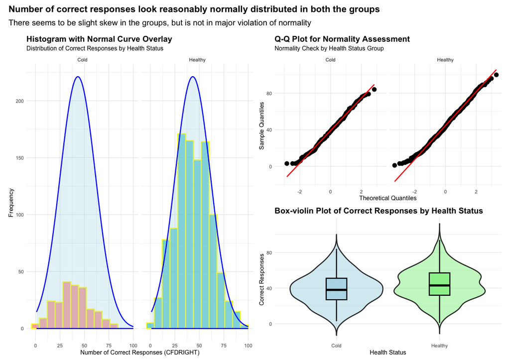

```r
bw = 8

p1 <- ggplot(nh, aes(Correct_Responses_Digit_Test, fill = Health_Status)) +
  geom_histogram(binwidth = bw, color = "yellow", alpha = 0.6, position = "identity") +
  stat_function(fun = function(x) {
    dnorm(x, mean = mean(nh$Correct_Responses_Digit_Test, na.rm = TRUE),
          sd = sd(nh$Correct_Responses_Digit_Test, na.rm = TRUE)) *
      length(nh$Correct_Responses_Digit_Test) * bw
  }, geom = "area", alpha = 0.3, fill = "lightblue", col = "blue") +
  facet_wrap(~ Health_Status) +
  labs(
    x = "Number of Correct Responses (CFDRIGHT)",
    y = "Frequency",
    title = "Histogram with Normal Curve Overlay",
    subtitle = "Distribution of Correct Responses by Health Status"
  ) +
  theme_minimal(base_size = 6) +
  theme(
    plot.title = element_text(size = 8, face = "bold"),
    plot.subtitle = element_text(size = 6)
  ) +
  guides(fill = "none")

p2 <- ggplot(nh, aes(sample = Correct_Responses_Digit_Test)) +
  stat_qq() +
  stat_qq_line(color = "red") +
  facet_wrap(~ Health_Status) +
  labs(
    x = "Theoretical Quantiles",
    y = "Sample Quantiles",
    title = "Q-Q Plot for Normality Assessment",
    subtitle = "Normality Check by Health Status Group"
  ) +
  theme_minimal(base_size = 6) +
  theme(
    plot.title = element_text(size = 8, face = "bold"),
    plot.subtitle = element_text(size = 6)
  )

p3 <- ggplot(nh, aes(x = Health_Status, y = Correct_Responses_Digit_Test, fill = Health_Status)) +
  geom_violin(trim = FALSE, alpha = 0.5) +
  geom_boxplot(width = 0.2, color = "black", alpha = 0.8, outlier.shape = NA) +
  labs(
    x = "Health Status",
    y = "Correct Responses",
    title = "Box-violin Plot of Correct Responses by Health Status"
  ) +
  theme_minimal(base_size = 6) +
  scale_fill_manual(values = c("Cold" = "lightblue", "Healthy" = "lightgreen")) +
  theme(
    plot.title = element_text(size = 8, face = "bold")
  ) +
  guides(fill = "none")

# Combine the plots vertically
combined_plot <- (p1 | (p2 / p3)) +
  plot_annotation(
    title = "Number of correct responses look reasonably normally distributed in both the groups",
    subtitle = "There seems to be slight skew in the groups, but is not in major violation of normality",
    theme = theme(
      plot.title = element_text(size = 9, face = "bold"),
      plot.subtitle = element_text(size = 8)
    )
  )

combined_plot
```

Examining the distributions, we see that the number of correct responses for both the Cold and Healthy groups follows a fairly normal pattern, with only slight skewness. This supports using a parametric confidence interval based on a t-distribution. The histogram, with an overlay of the normality curve, shows a bell-shaped distribution, suggesting normality. Additionally, the Q-Q plots indicate that the assumption of homogeneity of variance is reasonable, as the data points align closely with the theoretical quantile line, with only minor deviation in the lower tails, pointing to symmetry. Observations also appear to be independent, further supporting this approach.

# 5 Question 4

## 5.1 T-test

```r
levels(nh$Health_Status)
```

```
[1] "Cold"    "Healthy"
```

```r
fit2 <- t.test(Correct_Responses_Digit_Test ~ Health_Status, data = nh, var.equal = TRUE)

fit2 |>
  model_parameters(ci = 0.90) |>
  rename("Mean (Cold)" = Mean_Group1, "Mean (Healthy)" = Mean_Group2) |>
  kable(digits = 2)
```

| Parameter | Group | Mean (Cold) | Mean (Healthy) | Difference | CI | CI_low | CI_high | t | df_error | p | Method | Alternative |
| --- | --- | --- | --- | --- | --- | --- | --- | --- | --- | --- | --- | --- |
| Correct_Responses_Digit_Test | Health_Status | 38.77 | 44.24 | -5.47 | 0.9 | -8.1 | -2.84 | -4.08 | 1254 | 0 | Two Sample t-test | two.sided |

# 6 Question 5

We are dealing with **paired samples** because the data for both HSQ470 (physical health) and HSQ480 (mental health) are collected from the same respondents. This means that each observation in one group is directly related to an observation in the other group, allowing us to analyze the differences within individuals.

# 7 Question 9

## 7.1 Data ingestion and pre-processing

```r
lind <- read_rds("lab5_lind.Rds")
lind
```

```
# A tibble: 996 × 11
   lifepres cardbill abcix stent height female diabetic acutemi ejecfrac
      <dbl>    <int> <int> <int>  <int>  <int>    <int>   <int>    <int>
 1      0      14301     1     0    163      1        1       0       56
 2     11.6     3563     1     0    168      0        0       0       56
 3     11.6     4694     1     0    188      0        0       0       50
 4     11.6     7366     1     0    175      0        1       0       50
 5     11.6     8247     1     0    168      1        0       0       55
 6     11.6     8319     1     0    178      0        0       0       50
 7     11.6     8410     1     0    185      0        0       0       58
 8     11.6     8517     1     0    173      1        0       0       30
 9     11.6     8763     1     0    152      1        0       0       60
10     11.6     8823     1     0    180      0        0       0       60
# ℹ 986 more rows
# ℹ 2 more variables: ves1proc <int>, sixMonthSurvive <lgl>
```

```r
# Making the variables factors
lind$abcix <- as.factor(lind$abcix)
lind$acutemi <- as.factor(lind$acutemi)
lind$abcix <- fct_recode(lind$abcix, "Abcix" = "1", "Usual Care" = "0")
lind$acutemi <- fct_recode(lind$acutemi, "Acute MI" = "1", "No MI" = "0")
```

```r
lind <- lind |> mutate(abcix = fct_relevel(abcix, "Abcix"))
lind <- lind |> mutate(acutemi = fct_relevel(acutemi, "Acute MI"))

lind |> tabyl(abcix, acutemi)
```

```
      abcix Acute MI No MI
      Abcix      125   573
 Usual Care       18   280
```

## 7.2 Contingency Table

```r
twoby2(table(lind$abcix, lind$acutemi), conf.level = 0.90)
```

```
2 by 2 table analysis:
------------------------------------------------------
Outcome   : Acute MI
Comparing : Abcix vs. Usual Care

           Acute MI No MI    P(Acute MI) 90% conf. interval
Abcix           125   573         0.1791    0.1564   0.2042
Usual Care       18   280         0.0604    0.0413   0.0875

                                   90% conf. interval
             Relative Risk: 2.9648    1.9899   4.4174
         Sample Odds Ratio: 3.3934    2.2038   5.2253
Conditional MLE Odds Ratio: 3.3900    2.1647   5.4945
    Probability difference: 0.1187    0.0835   0.1501

             Exact P-value: 0.0000
        Asymptotic P-value: 0.0000
------------------------------------------------------
```

```r
lind |> tabyl(abcix, acutemi) |>
  adorn_totals(where = c("row", "col")) |>
  adorn_percentages(denom = "row") |>
  adorn_pct_formatting(digits = 1) |>
  adorn_ns(position = "front")
```

```
      abcix    Acute MI       No MI        Total
      Abcix 125 (17.9%) 573 (82.1%) 698 (100.0%)
 Usual Care  18  (6.0%) 280 (94.0%) 298 (100.0%)
      Total 143 (14.4%) 853 (85.6%) 996 (100.0%)
```

The relative risk of having an acute myocardial infarction (MI) for those receiving abciximab compared to those receiving usual care is 2.96. This indicates that individuals receiving abciximab are approximately 2.96 times more likely to experience an acute MI than those receiving usual care.

# 8 Question 10

```r
TP <- 405
FN <- 74
TN <- 9
FP <- 495 - TP - FN - TN


error_matrix <- data.frame(
  "Predicted to survive" = c(TP, FP),
  "Predicted not to survive" = c(FN, TN),
  row.names = c("Survived", "Did not survive")
)
error_matrix
```

```
                Predicted.to.survive Predicted.not.to.survive
Survived                         405                       74
Did not survive                    7                        9
```

```r
total_patients <- 495
accuracy <- (TP + TN) / total_patients
sensitivity <- TP / (TP + FN)
specificity <- TN / (TN + FP)

cat("\nPerformance Metrics:\n")
```

```
Performance Metrics:
```

```r
cat("Accuracy:", round(accuracy, 3), "\n")
```

```
Accuracy: 0.836
```

```r
cat("Sensitivity:", round(sensitivity, 3), "\n")
```

```
Sensitivity: 0.846
```

```r
cat("Specificity:", round(specificity, 3), "\n")
```

```
Specificity: 0.562
```

The model’s performance shows an accuracy of 83.6%, meaning it correctly classified cases in about 84 out of every 100 instances. The sensitivity, or the true positive rate, is 84.6%, indicating that the model successfully identified 85% of the positive cases. However, the specificity, which measures the ability to correctly identify negative cases, is lower at 56.2%, showing that the model accurately classified about 56% of the negative cases. This suggests the model performs well in detecting positives but may need improvement in identifying negatives accurately.